# Heart Disease — exploration statistique et choix des visualisations

Ce notebook est un espace de travail indépendant pour **choisir les graphiques avant leur éventuelle intégration dans Shiny**. Ouvrir ce fichier dans RStudio, exécuter les cellules dans l’ordre ou cliquer sur **Preview**. Pour reconstruire l’aperçu depuis la racine du projet : `rmarkdown::render("exploration_statistique.Rmd")`.

La démarche suit : import et qualité → description univariée → comparaisons selon le diagnostic → relations entre variables → exploration multivariée → sélection des graphiques. Les analyses portent sur les quatre fichiers UCI `processed` du projet ; `heart.csv` est une autre version et n’est pas mélangé à ces données. Aucune imputation n’est effectuée.

## 1 Préparation et paramètres

Dépendances : `install.packages(c("ggplot2", "knitr", "rmarkdown"))` dans la console si nécessaire. Modifier `centres_retenus` pour explorer un centre, `variable_x` et `variable_y` pour changer le nuage de points.

```r
knitr::opts_chunk$set(echo = TRUE, fig.width = 11, fig.height = 7,
                     dpi = 120, warning = TRUE, message = FALSE)
stopifnot(requireNamespace("ggplot2", quietly = TRUE))
library(ggplot2)
Sys.setenv(TZ = "Europe/Paris")
set.seed(2026)
centres_retenus <- c("cleveland", "hungarian", "switzerland", "va")
variable_x <- "age"
variable_y <- "fc_max"
palette_diagnostic <- c("Code 0" = "#2878B5", "Codes 1–4" = "#D55E00")
theme_set(theme_minimal(base_size = 12))
theme_update(panel.grid.minor = element_blank(),
             plot.title = element_text(face = "bold"))
```

## 2 Import et contrôle de qualité

Réutiliser `R/import.R` permet d’appliquer exactement les règles actuelles du projet : `?` devient `NA`, une occurrence par profil répété dans un même centre est conservée, les zéros de pression au repos et de cholestérol deviennent `NA`. Un profil répété ne prouve pas qu’il s’agit du même patient. Les fichiers sources restent intacts. L’import s’exécute dans un environnement séparé ; son graphique initial est intercepté, puis les graphiques du notebook sont construits ici.

```r
tableau(import_uci$bilan_nettoyage)
```

| n_brut | n_doublons_retires | n_final | n_zeros_recodes |
| --- | --- | --- | --- |
| 920 | 2 | 918 | 173 |

```r
tableau(import_uci$journal_recodage[
  import_uci$journal_recodage$provenance %in% centres_retenus, ])
```

| provenance | variable | n_observations | n_na_initiaux | n_zeros_recodes | n_na_finaux | pct_na_finaux |
| --- | --- | --- | --- | --- | --- | --- |
| cleveland | pa_repos | 303 | 0 | 0 | 0 | 0.00 |
| cleveland | cholesterol | 303 | 0 | 0 | 0 | 0.00 |
| hungarian | pa_repos | 293 | 1 | 0 | 1 | 0.34 |
| hungarian | cholesterol | 293 | 22 | 0 | 22 | 7.51 |
| switzerland | pa_repos | 123 | 2 | 0 | 2 | 1.63 |
| switzerland | cholesterol | 123 | 0 | 123 | 123 | 100.00 |
| va | pa_repos | 199 | 56 | 1 | 57 | 28.64 |
| va | cholesterol | 199 | 7 | 49 | 56 | 28.14 |

```r
tableau(head(d))
```

| age | sexe | type_doul_thor | pa_repos | cholesterol | glyc_jeun_elevee | ecg_repos | fc_max | angine_effort | depress_st | pente_st | nb_vaisseaux | test_thallium | diagnostic | provenance | diagnostic_initial |
| --- | --- | --- | --- | --- | --- | --- | --- | --- | --- | --- | --- | --- | --- | --- | --- |
| 63 | Homme | Angine typique | 145 | 233 | > 120 mg/dL | Hypertrophie VG | 150 | Non | 2.3 | Descendante | 0 | Défaut fixe | Code 0 | Cleveland | 0 |
| 67 | Homme | Asymptomatique | 160 | 286 | ≤ 120 mg/dL | Hypertrophie VG | 108 | Oui | 1.5 | Plate | 3 | Normal | Codes 1–4 | Cleveland | 2 |
| 67 | Homme | Asymptomatique | 120 | 229 | ≤ 120 mg/dL | Hypertrophie VG | 129 | Oui | 2.6 | Plate | 2 | Défaut réversible | Codes 1–4 | Cleveland | 1 |
| 37 | Homme | Douleur non angineuse | 130 | 250 | ≤ 120 mg/dL | Normal | 187 | Non | 3.5 | Descendante | 0 | Normal | Code 0 | Cleveland | 0 |
| 41 | Femme | Angine atypique | 130 | 204 | ≤ 120 mg/dL | Hypertrophie VG | 172 | Non | 1.4 | Montante | 0 | Normal | Code 0 | Cleveland | 0 |
| 56 | Homme | Angine atypique | 120 | 236 | ≤ 120 mg/dL | Normal | 178 | Non | 0.8 | Montante | 0 | Normal | Code 0 | Cleveland | 0 |

```r
dictionnaire <- import_uci$dictionnaire
dictionnaire$type <- ifelse(dictionnaire$nom_fr %in% quanti, "Quantitative",
                            ifelse(dictionnaire$nom_fr == "diagnostic",
                                   "Cible (codes 0–4, puis binaire)", "Catégorielle"))
tableau(dictionnaire)
```

| nom_uci | nom_fr | libelle | type |
| --- | --- | --- | --- |
| age | age | Âge (ans) | Quantitative |
| sex | sexe | Sexe | Catégorielle |
| cp | type_doul_thor | Type de douleur thoracique | Catégorielle |
| trestbps | pa_repos | Pression artérielle au repos (mmHg) | Quantitative |
| chol | cholesterol | Cholestérol (mg/dL) | Quantitative |
| fbs | glyc_jeun_elevee | Glycémie à jeun > 120 mg/dL | Catégorielle |
| restecg | ecg_repos | ECG au repos | Catégorielle |
| thalach | fc_max | Fréquence cardiaque maximale | Quantitative |
| exang | angine_effort | Angine à l’effort | Catégorielle |
| oldpeak | depress_st | Dépression du segment ST | Quantitative |
| slope | pente_st | Pente du segment ST | Catégorielle |
| ca | nb_vaisseaux | Nombre de vaisseaux visualisés | Catégorielle |
| thal | test_thallium | Résultat du test au thallium | Catégorielle |
| num | diagnostic | Diagnostic (code 0–4) | Cible (codes 0–4, puis binaire) |

Le premier bilan concerne les quatre sources ; les analyses suivantes concernent uniquement les centres sélectionnés. Les codes 1–4 sont regroupés pour les comparaisons binaires, tandis que le code original est conservé. Ces codes ne sont pas traités comme une mesure quantitative de sévérité.

### 2.1 Données manquantes et composition des centres

**V01 — Carte des valeurs manquantes.** Le dénominateur est l’effectif du centre. Les analyses univariées utilisent les valeurs disponibles, les corrélations les paires disponibles, et l’ACP les lignes complètes sur ses cinq mesures.

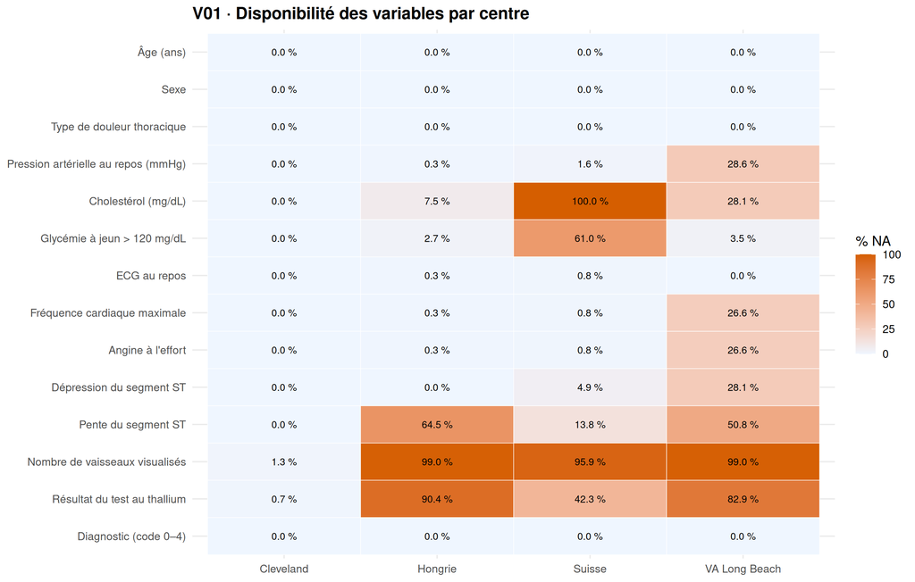

```r
variables <- import_uci$colonnes
bilan_na <- do.call(rbind, lapply(levels(d$provenance), function(s) {
  z <- d[d$provenance == s, variables]
  data.frame(centre = s, variable = variables, n = nrow(z),
             n_na = colSums(is.na(z)), pct_na = 100 * colMeans(is.na(z)))
}))
bilan_na$variable <- factor(bilan_na$variable, levels = rev(variables))
ggplot(bilan_na, aes(centre, variable, fill = pct_na)) +
  geom_tile(color = "white") + geom_text(aes(label = sprintf("%.1f %%", pct_na)), size = 3) +
  scale_fill_gradient(low = "#EFF6FF", high = "#D55E00", limits = c(0, 100), name = "% NA") +
  scale_y_discrete(labels = libelles) +
  labs(title = "V01 · Disponibilité des variables par centre", x = NULL, y = NULL)
```

```r
composition <- as.data.frame(table(d$provenance, d$diagnostic, useNA = "ifany"))
names(composition) <- c("centre", "diagnostic", "n")
tableau(composition)
```

| centre | diagnostic | n |
| --- | --- | --- |
| Cleveland | Code 0 | 164 |
| Hongrie | Code 0 | 187 |
| Suisse | Code 0 | 8 |
| VA Long Beach | Code 0 | 51 |
| Cleveland | Codes 1–4 | 139 |
| Hongrie | Codes 1–4 | 106 |
| Suisse | Codes 1–4 | 115 |
| VA Long Beach | Codes 1–4 | 148 |

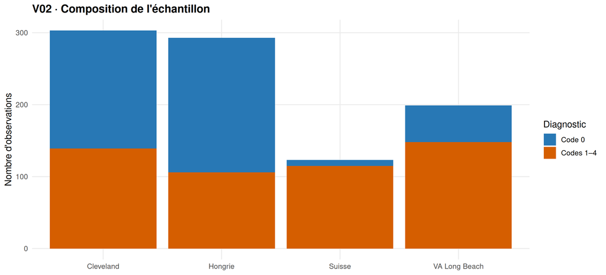

```r
ggplot(subset(composition, !is.na(diagnostic)), aes(centre, n, fill = diagnostic)) +
  geom_col() + scale_fill_manual(values = palette_diagnostic) +
  labs(title = "V02 · Composition de l'échantillon", x = NULL,
       y = "Nombre d'observations", fill = "Diagnostic")
```

```r
tableau(as.data.frame(table(code_original = d$diagnostic_initial, useNA = "ifany")))
```

| code_original | Freq |
| --- | --- |
| 0 | 410 |
| 1 | 265 |
| 2 | 108 |
| 3 | 107 |
| 4 | 28 |

## 3 Description univariée

### 3.1 Mesures quantitatives

Effectifs et NA sont affichés pour chaque variable. La médiane et l’intervalle interquartile complètent la moyenne et l’écart type lorsque la distribution est asymétrique. Les valeurs extrêmes restent dans les données.

```r
resumer <- function(x) {
  z <- x[!is.na(x)]
  if (!length(z)) return(data.frame(n = 0, n_na = length(x), moyenne = NA_real_,
    ecart_type = NA_real_, minimum = NA_real_, q1 = NA_real_, mediane = NA_real_,
    q3 = NA_real_, maximum = NA_real_))
  data.frame(n = length(z), n_na = sum(is.na(x)), moyenne = mean(z),
    ecart_type = sd(z), minimum = min(z), q1 = unname(quantile(z, .25)),
    mediane = median(z), q3 = unname(quantile(z, .75)), maximum = max(z))
}
resume_quanti <- do.call(rbind, lapply(quanti, function(v) {
  data.frame(variable = unname(libelles[v]), resumer(d[[v]]))
}))
tableau(resume_quanti)
```

| variable | n | n_na | moyenne | ecart_type | minimum | q1 | mediane | q3 | maximum |
| --- | --- | --- | --- | --- | --- | --- | --- | --- | --- |
| Âge (ans) | 918 | 0 | 53.51 | 9.43 | 28.0 | 47 | 54.0 | 60.0 | 77.0 |
| Pression artérielle au repos (mmHg) | 858 | 60 | 132.29 | 18.53 | 80.0 | 120 | 130.0 | 140.0 | 200.0 |
| Cholestérol (mg/dL) | 717 | 201 | 246.87 | 58.56 | 85.0 | 210 | 240.0 | 277.0 | 603.0 |
| Fréquence cardiaque maximale | 863 | 55 | 137.54 | 25.94 | 60.0 | 120 | 140.0 | 157.0 | 202.0 |
| Dépression du segment ST | 856 | 62 | 0.88 | 1.09 | -2.6 | 0 | 0.5 | 1.5 | 6.2 |

**V03 — Histogrammes.** Comparer dispersion, asymétrie et éventuels amas de valeurs. Les unités et échelles diffèrent selon les facettes.

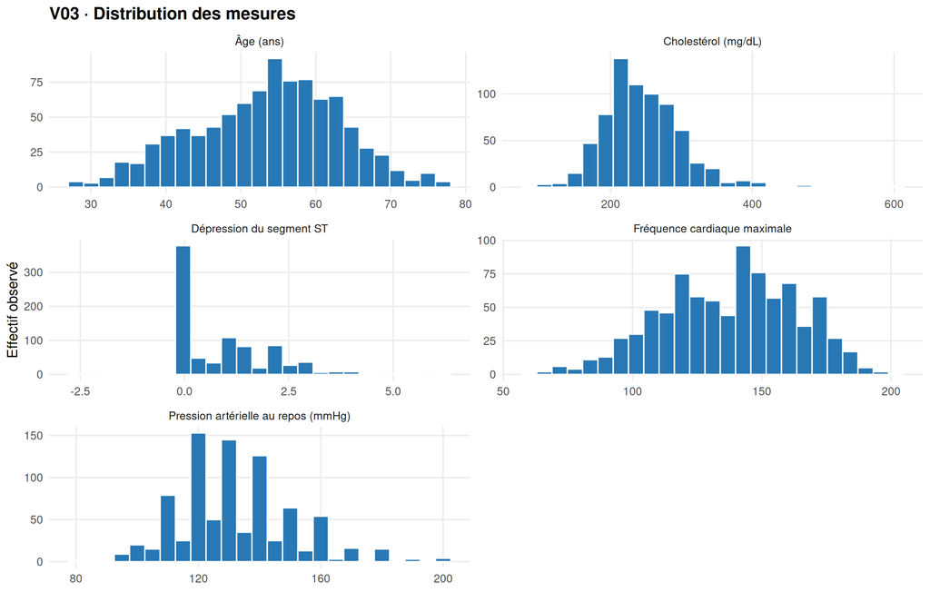

```r
ggplot(subset(long_quanti, !is.na(valeur)), aes(valeur)) +
  geom_histogram(bins = 25, fill = "#2878B5", color = "white") +
  facet_wrap(~variable, scales = "free", ncol = 2) +
  labs(title = "V03 · Distribution des mesures", x = NULL, y = "Effectif observé")
```

### 3.2 Variables catégorielles

**V04 — Fréquences des modalités.** Les NA sont une catégorie de disponibilité, pas une modalité clinique. Les proportions du tableau incluent les NA au dénominateur pour rendre leur poids visible.

```r
frequences <- do.call(rbind, lapply(quali, function(v) {
  x <- as.character(d[[v]])
  x[is.na(x)] <- "Manquant"
  t <- as.data.frame(table(x), stringsAsFactors = FALSE)
  data.frame(variable = unname(libelles[v]), modalite = t$x,
             n = t$Freq, pct = 100 * t$Freq / nrow(d))
}))
tableau(frequences)
```

| variable | modalite | n | pct |
| --- | --- | --- | --- |
| Sexe | Femme | 193 | 21.02 |
| Sexe | Homme | 725 | 78.98 |
| Type de douleur thoracique | Angine atypique | 173 | 18.85 |
| Type de douleur thoracique | Angine typique | 46 | 5.01 |
| Type de douleur thoracique | Asymptomatique | 496 | 54.03 |
| Type de douleur thoracique | Douleur non angineuse | 203 | 22.11 |
| Glycémie à jeun > 120 mg/dL | > 120 mg/dL | 138 | 15.03 |
| Glycémie à jeun > 120 mg/dL | ≤ 120 mg/dL | 690 | 75.16 |
| Glycémie à jeun > 120 mg/dL | Manquant | 90 | 9.80 |
| ECG au repos | Anomalie ST-T | 178 | 19.39 |
| ECG au repos | Hypertrophie VG | 188 | 20.48 |
| ECG au repos | Manquant | 2 | 0.22 |
| ECG au repos | Normal | 550 | 59.91 |
| Angine à l’effort | Manquant | 55 | 5.99 |
| Angine à l’effort | Non | 527 | 57.41 |
| Angine à l’effort | Oui | 336 | 36.60 |
| Pente du segment ST | Descendante | 63 | 6.86 |
| Pente du segment ST | Manquant | 307 | 33.44 |
| Pente du segment ST | Montante | 203 | 22.11 |
| Pente du segment ST | Plate | 345 | 37.58 |
| Nombre de vaisseaux visualisés | 0 | 181 | 19.72 |
| Nombre de vaisseaux visualisés | 1 | 67 | 7.30 |
| Nombre de vaisseaux visualisés | 2 | 41 | 4.47 |
| Nombre de vaisseaux visualisés | 3 | 20 | 2.18 |
| Nombre de vaisseaux visualisés | Manquant | 609 | 66.34 |
| Résultat du test au thallium | Défaut fixe | 46 | 5.01 |
| Résultat du test au thallium | Défaut réversible | 192 | 20.92 |
| Résultat du test au thallium | Manquant | 484 | 52.72 |
| Résultat du test au thallium | Normal | 196 | 21.35 |

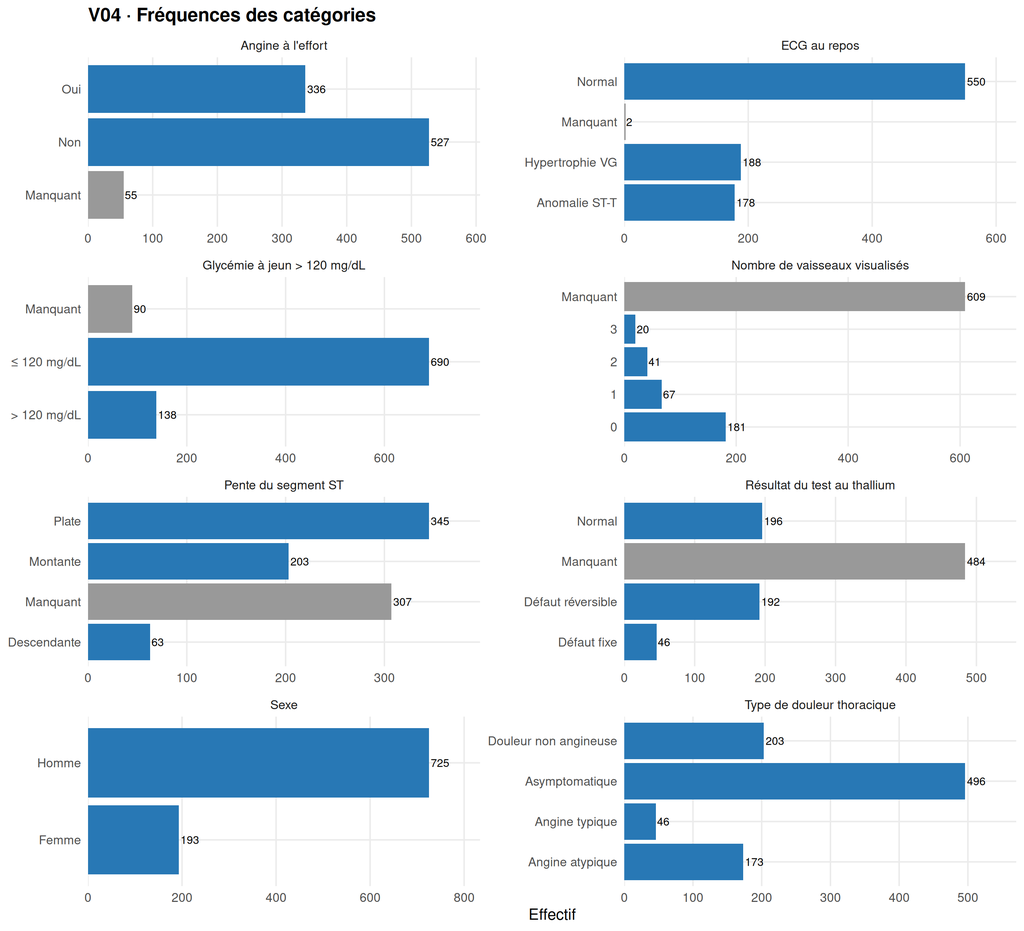

```r
ggplot(frequences, aes(n, modalite, fill = modalite == "Manquant")) +
  geom_col(show.legend = FALSE) + geom_text(aes(label = n), hjust = -.1, size = 3) +
  scale_fill_manual(values = c("FALSE" = "#2878B5", "TRUE" = "#999999")) +
  scale_x_continuous(expand = expansion(mult = c(0, .15))) +
  facet_wrap(~variable, scales = "free", ncol = 2) +
  labs(title = "V04 · Fréquences des catégories", x = "Effectif", y = NULL)
```

## 4 Comparaisons selon le diagnostic

### 4.1 Mesures quantitatives : distributions et effets de centre

**V05 — Boîtes et observations.** Les points au-delà des moustaches ne sont pas supprimés. Le tableau indique combien de mesures sont disponibles dans chaque groupe. **V06** répète la comparaison par centre : une différence globale peut refléter la composition des centres.

```r
resume_groupes <- do.call(rbind, lapply(levels(d$diagnostic), function(g) {
  z <- d[!is.na(d$diagnostic) & d$diagnostic == g, ]
  do.call(rbind, lapply(quanti, function(v) {
    data.frame(diagnostic = g, variable = unname(libelles[v]), resumer(z[[v]]))
  }))
}))
tableau(resume_groupes)
```

| diagnostic | variable | n | n_na | moyenne | ecart_type | minimum | q1 | mediane | q3 | maximum |
| --- | --- | --- | --- | --- | --- | --- | --- | --- | --- | --- |
| Code 0 | Âge (ans) | 410 | 0 | 50.55 | 9.44 | 28.0 | 43.00 | 51.0 | 57.00 | 76.0 |
| Code 0 | Pression artérielle au repos (mmHg) | 390 | 20 | 129.96 | 16.86 | 80.0 | 120.00 | 130.0 | 140.00 | 190.0 |
| Code 0 | Cholestérol (mg/dL) | 372 | 38 | 240.16 | 55.77 | 85.0 | 204.00 | 233.0 | 270.25 | 564.0 |
| Code 0 | Fréquence cardiaque maximale | 390 | 20 | 148.77 | 23.63 | 69.0 | 134.25 | 151.0 | 167.75 | 202.0 |
| Code 0 | Dépression du segment ST | 389 | 21 | 0.42 | 0.72 | -1.1 | 0.00 | 0.0 | 0.80 | 4.2 |
| Codes 1–4 | Âge (ans) | 508 | 0 | 55.90 | 8.73 | 31.0 | 51.00 | 57.0 | 62.00 | 77.0 |
| Codes 1–4 | Pression artérielle au repos (mmHg) | 468 | 40 | 134.23 | 19.63 | 92.0 | 120.00 | 130.0 | 145.00 | 200.0 |
| Codes 1–4 | Cholestérol (mg/dL) | 345 | 163 | 254.11 | 60.68 | 100.0 | 216.00 | 248.0 | 285.00 | 603.0 |
| Codes 1–4 | Fréquence cardiaque maximale | 473 | 35 | 128.28 | 24.04 | 60.0 | 112.00 | 128.0 | 145.00 | 195.0 |
| Codes 1–4 | Dépression du segment ST | 467 | 41 | 1.27 | 1.20 | -2.6 | 0.00 | 1.1 | 2.00 | 6.2 |

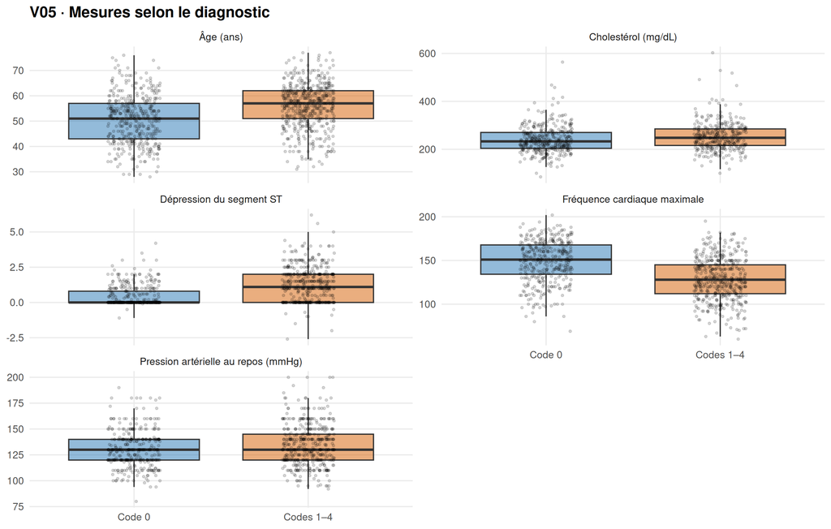

```r
observes <- subset(long_quanti, !is.na(valeur) & !is.na(diagnostic))
ggplot(observes, aes(diagnostic, valeur, fill = diagnostic)) +
  geom_boxplot(outlier.shape = NA, alpha = .5) +
  geom_jitter(width = .15, height = 0, alpha = .15, size = .8) +
  facet_wrap(~variable, scales = "free_y", ncol = 2) +
  scale_fill_manual(values = palette_diagnostic, guide = "none") +
  labs(title = "V05 · Mesures selon le diagnostic", x = NULL, y = NULL)
```

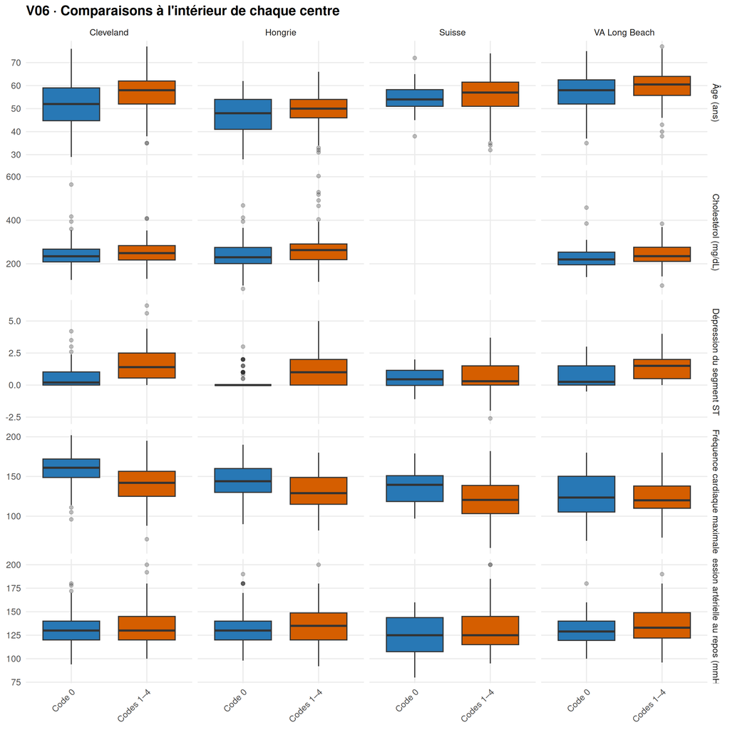

```r
ggplot(observes, aes(diagnostic, valeur, fill = diagnostic)) +
  geom_boxplot(outlier.alpha = .3) +
  facet_grid(variable ~ provenance, scales = "free_y") +
  scale_fill_manual(values = palette_diagnostic, guide = "none") +
  labs(title = "V06 · Comparaisons à l'intérieur de chaque centre", x = NULL, y = NULL) +
  theme(axis.text.x = element_text(angle = 45, hjust = 1))
```

### 4.2 Variables catégorielles : proportions conditionnelles

**V07 — Proportion de diagnostics positifs par modalité.** Chaque dénominateur comprend les observations avec une modalité et un diagnostic disponibles. Afficher les effectifs évite de donner le même poids à une petite catégorie et à une catégorie fréquente. Les intervalles de Wilson à 95 % décrivent la précision des proportions sous une hypothèse d’observations indépendantes ; ils ne corrigent pas les différences de recrutement entre centres.

```r
proportions <- do.call(rbind, lapply(quali, function(v) {
  garder <- !is.na(d[[v]]) & !is.na(d$diagnostic)
  groupes <- split(d$diagnostic[garder], droplevels(d[[v]][garder]))
  do.call(rbind, lapply(names(groupes), function(m) {
    n <- length(groupes[[m]])
    k <- sum(groupes[[m]] == "Codes 1–4")
    p <- k / n
    z <- qnorm(.975)
    centre <- (p + z^2 / (2 * n)) / (1 + z^2 / n)
    marge <- z * sqrt(p * (1 - p) / n + z^2 / (4 * n^2)) / (1 + z^2 / n)
    data.frame(variable = unname(libelles[v]), modalite = m, n = n,
               positifs = k, proportion = p, bas = centre - marge, haut = centre + marge)
  }))
}))
tableau(proportions)
```

| variable | modalite | n | positifs | proportion | bas | haut |
| --- | --- | --- | --- | --- | --- | --- |
| Sexe | Femme | 193 | 50 | 0.26 | 0.20 | 0.33 |
| Sexe | Homme | 725 | 458 | 0.63 | 0.60 | 0.67 |
| Type de douleur thoracique | Angine typique | 46 | 20 | 0.43 | 0.30 | 0.58 |
| Type de douleur thoracique | Angine atypique | 173 | 24 | 0.14 | 0.10 | 0.20 |
| Type de douleur thoracique | Douleur non angineuse | 203 | 72 | 0.35 | 0.29 | 0.42 |
| Type de douleur thoracique | Asymptomatique | 496 | 392 | 0.79 | 0.75 | 0.82 |
| Glycémie à jeun > 120 mg/dL | ≤ 120 mg/dL | 690 | 338 | 0.49 | 0.45 | 0.53 |
| Glycémie à jeun > 120 mg/dL | > 120 mg/dL | 138 | 94 | 0.68 | 0.60 | 0.75 |
| ECG au repos | Normal | 550 | 283 | 0.51 | 0.47 | 0.56 |
| ECG au repos | Anomalie ST-T | 178 | 117 | 0.66 | 0.58 | 0.72 |
| ECG au repos | Hypertrophie VG | 188 | 106 | 0.56 | 0.49 | 0.63 |
| Angine à l’effort | Non | 527 | 192 | 0.36 | 0.32 | 0.41 |
| Angine à l’effort | Oui | 336 | 281 | 0.84 | 0.79 | 0.87 |
| Pente du segment ST | Montante | 203 | 78 | 0.38 | 0.32 | 0.45 |
| Pente du segment ST | Plate | 345 | 266 | 0.77 | 0.72 | 0.81 |
| Pente du segment ST | Descendante | 63 | 49 | 0.78 | 0.66 | 0.86 |
| Nombre de vaisseaux visualisés | 0 | 181 | 48 | 0.27 | 0.21 | 0.33 |
| Nombre de vaisseaux visualisés | 1 | 67 | 46 | 0.69 | 0.57 | 0.78 |
| Nombre de vaisseaux visualisés | 2 | 41 | 33 | 0.80 | 0.66 | 0.90 |
| Nombre de vaisseaux visualisés | 3 | 20 | 17 | 0.85 | 0.64 | 0.95 |
| Résultat du test au thallium | Normal | 196 | 58 | 0.30 | 0.24 | 0.36 |
| Résultat du test au thallium | Défaut fixe | 46 | 35 | 0.76 | 0.62 | 0.86 |
| Résultat du test au thallium | Défaut réversible | 192 | 154 | 0.80 | 0.74 | 0.85 |

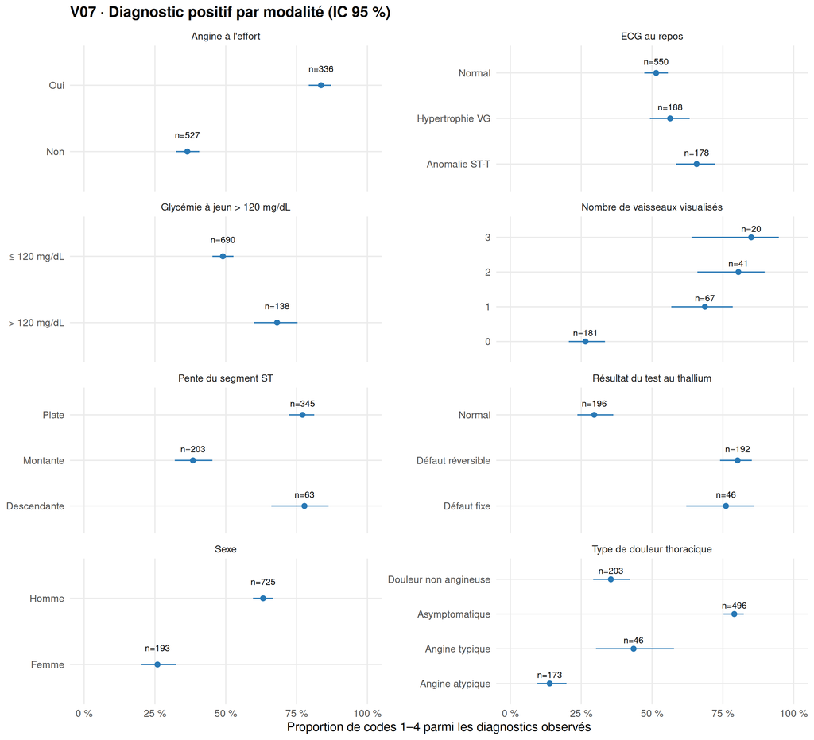

```r
ggplot(proportions, aes(proportion, modalite)) +
  geom_segment(aes(x = bas, xend = haut, yend = modalite), color = "#2878B5") +
  geom_point(color = "#2878B5", size = 2) +
  geom_text(aes(label = paste0("n=", n)), nudge_y = .25, size = 3) +
  facet_wrap(~variable, scales = "free_y", ncol = 2) +
  scale_x_continuous(limits = c(0, 1), labels = function(x) paste0(round(100*x), " %")) +
  labs(title = "V07 · Diagnostic positif par modalité (IC 95 %)",
       x = "Proportion de codes 1–4 parmi les diagnostics observés", y = NULL)
```

## 5 Relations entre mesures quantitatives

### 5.1 Corrélations de Spearman et effectifs par paire

**V08 — Carte des corrélations.** Spearman décrit les relations monotones et limite l’influence des valeurs extrêmes. Le diagnostic et les codes de catégories n’entrent pas dans cette matrice. Chaque cellule repose sur ses propres observations disponibles : ces coefficients peuvent donc concerner des sous-échantillons différents. Une corrélation ne démontre pas de causalité.

```r
correlations <- cor(d[quanti], use = "pairwise.complete.obs", method = "spearman")
effectifs_paires <- crossprod(1L * !is.na(as.matrix(d[quanti])))
tableau(data.frame(variable = quanti, correlations, check.names = FALSE))
```

| variable | age | pa_repos | cholesterol | fc_max | depress_st |
| --- | --- | --- | --- | --- | --- |
| age | 1.00 | 0.26 | 0.10 | -0.35 | 0.29 |
| pa_repos | 0.26 | 1.00 | 0.09 | -0.09 | 0.16 |
| cholesterol | 0.10 | 0.09 | 1.00 | -0.03 | 0.07 |
| fc_max | -0.35 | -0.09 | -0.03 | 1.00 | -0.19 |
| depress_st | 0.29 | 0.16 | 0.07 | -0.19 | 1.00 |

```r
tableau(data.frame(variable = quanti, effectifs_paires, check.names = FALSE))
```

| variable | age | pa_repos | cholesterol | fc_max | depress_st |
| --- | --- | --- | --- | --- | --- |
| age | 918 | 858 | 717 | 863 | 856 |
| pa_repos | 858 | 858 | 674 | 858 | 851 |
| cholesterol | 717 | 674 | 717 | 675 | 673 |
| fc_max | 863 | 858 | 675 | 863 | 855 |
| depress_st | 856 | 851 | 673 | 855 | 856 |

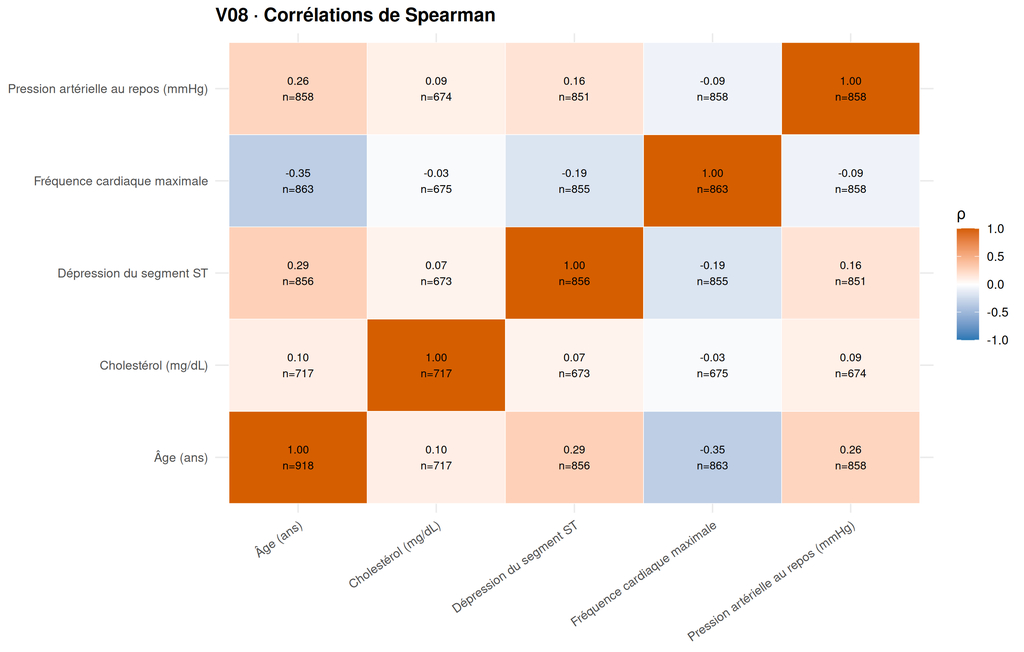

```r
carte_cor <- expand.grid(x = quanti, y = quanti, stringsAsFactors = FALSE)
carte_cor$rho <- as.vector(correlations)
carte_cor$n <- as.vector(effectifs_paires)
ggplot(carte_cor, aes(x, y, fill = rho)) +
  geom_tile(color = "white") +
  geom_text(aes(label = ifelse(is.na(rho), paste0("NA\nn=", n),
                              sprintf("%.2f\nn=%d", rho, n))), size = 3) +
  scale_fill_gradient2(low = "#2878B5", mid = "white", high = "#D55E00",
                       midpoint = 0, limits = c(-1, 1), name = "ρ") +
  scale_x_discrete(labels = libelles) + scale_y_discrete(labels = libelles) +
  labs(title = "V08 · Corrélations de Spearman", x = NULL, y = NULL) +
  theme(axis.text.x = element_text(angle = 35, hjust = 1))
```

### 5.2 Nuage de points personnalisable

**V09 — Relation entre deux mesures.** Les facettes permettent de comparer les centres, la couleur de comparer les diagnostics. Modifier les paramètres de la première cellule pour essayer d’autres couples. Les points sont transparents pour rendre visibles les superpositions.

```r
stopifnot(variable_x %in% quanti, variable_y %in% quanti, variable_x != variable_y)
paire <- d[complete.cases(d[c(variable_x, variable_y, "diagnostic")]), ]
tableau(as.data.frame(table(centre = paire$provenance)))
```

| centre | Freq |
| --- | --- |
| Cleveland | 303 |
| Hongrie | 292 |
| Suisse | 122 |
| VA Long Beach | 146 |

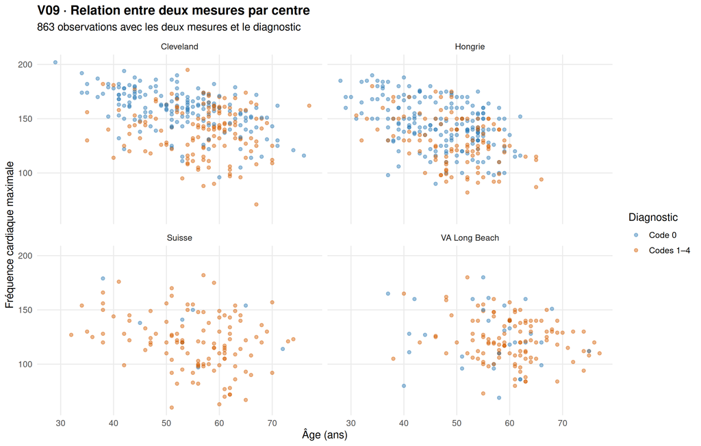

```r
ggplot(paire, aes(x = .data[[variable_x]], y = .data[[variable_y]], color = diagnostic)) +
  geom_point(alpha = .45, size = 1.5) + facet_wrap(~provenance) +
  scale_color_manual(values = palette_diagnostic) +
  labs(title = "V09 · Relation entre deux mesures par centre",
       subtitle = paste(nrow(paire), "observations avec les deux mesures et le diagnostic"),
       x = libelles[[variable_x]], y = libelles[[variable_y]], color = "Diagnostic")
```

## 6 Tests exploratoires d’association

Les tests complètent les graphiques. Pour les mesures, le test de Wilcoxon compare les distributions des deux groupes ; son interprétation comme différence de médianes demande des formes de distribution comparables. Pour les catégories, un χ² est utilisé si tous les effectifs attendus sont ≥ 5, sinon sa p-valeur est simulée avec 10 000 tirages. Les effectifs et le V de Cramér sont fournis. Les p-valeurs sont corrigées ensemble par Benjamini–Hochberg. Ces comparaisons restent exploratoires, sans ajustement sur le centre ni interprétation causale.

```r
tests_quanti <- do.call(rbind, lapply(quanti, function(v) {
  z <- d[complete.cases(d[c(v, "diagnostic")]), ]
  p <- if (all(table(z$diagnostic) >= 2) && length(unique(z[[v]])) > 1)
    wilcox.test(z[[v]] ~ z$diagnostic, exact = FALSE)$p.value else NA_real_
  data.frame(variable = unname(libelles[v]), n = nrow(z),
             test = "Wilcoxon", V_cramer = NA_real_, p = p)
}))
tests_quali <- do.call(rbind, lapply(quali, function(v) {
  z <- d[complete.cases(d[c(v, "diagnostic")]), ]
  t <- table(droplevels(z[[v]]), droplevels(z$diagnostic))
  p <- effet <- NA_real_
  methode <- "Non calculable"
  if (all(dim(t) >= 2)) {
    attendu <- outer(rowSums(t), colSums(t)) / sum(t)
    simuler <- any(attendu < 5)
    test <- chisq.test(t, correct = FALSE, simulate.p.value = simuler, B = 10000)
    p <- test$p.value
    # V de Cramér calculé avec la statistique de Pearson sans correction.
    effet <- sqrt(sum((t - attendu)^2 / attendu) / (sum(t) * min(dim(t) - 1)))
    methode <- if (simuler) "χ² simulé (10 000)" else "χ² de Pearson"
  }
  data.frame(variable = unname(libelles[v]), n = nrow(z),
             test = methode, V_cramer = effet, p = p)
}))
associations <- rbind(tests_quanti, tests_quali)
associations$p_BH <- p.adjust(associations$p, method = "BH")
tableau(associations, digits = 4)
```

| variable | n | test | V_cramer | p | p_BH |
| --- | --- | --- | --- | --- | --- |
| Âge (ans) | 918 | Wilcoxon | NA | 0.0000 | 0.0000 |
| Pression artérielle au repos (mmHg) | 858 | Wilcoxon | NA | 0.0017 | 0.0019 |
| Cholestérol (mg/dL) | 717 | Wilcoxon | NA | 0.0006 | 0.0008 |
| Fréquence cardiaque maximale | 863 | Wilcoxon | NA | 0.0000 | 0.0000 |
| Dépression du segment ST | 856 | Wilcoxon | NA | 0.0000 | 0.0000 |
| Sexe | 918 | χ² de Pearson | 0.3054 | 0.0000 | 0.0000 |
| Type de douleur thoracique | 918 | χ² de Pearson | 0.5404 | 0.0000 | 0.0000 |
| Glycémie à jeun > 120 mg/dL | 828 | χ² de Pearson | 0.1427 | 0.0000 | 0.0001 |
| ECG au repos | 916 | χ² de Pearson | 0.1106 | 0.0037 | 0.0037 |
| Angine à l’effort | 863 | χ² de Pearson | 0.4624 | 0.0000 | 0.0000 |
| Pente du segment ST | 611 | χ² de Pearson | 0.3813 | 0.0000 | 0.0000 |
| Nombre de vaisseaux visualisés | 309 | χ² de Pearson | 0.4867 | 0.0000 | 0.0000 |
| Résultat du test au thallium | 434 | χ² de Pearson | 0.5013 | 0.0000 | 0.0000 |

## 7 Exploration multivariée : ACP des mesures quantitatives

L’ACP est centrée et réduite pour donner aux cinq mesures le même poids malgré leurs unités différentes. Elle utilise uniquement les cas complets sur ces mesures. Le diagnostic et le centre servent à lire les projections et ne construisent pas les axes. Cette sélection peut modifier la composition de l’échantillon : comparer le tableau ci-dessous au tableau de composition initial. Les variables catégorielles ne sont pas incluses comme nombres dans l’ACP.

```r
complets <- complete.cases(d[quanti])
d_acp <- d[complets, ]
bilan_acp <- do.call(rbind, lapply(levels(d$provenance), function(s) {
  data.frame(centre = s, n_initial = sum(d$provenance == s),
             n_acp = sum(d_acp$provenance == s))
}))
bilan_acp$pct_conserve <- 100 * bilan_acp$n_acp / bilan_acp$n_initial
tableau(bilan_acp)
```

| centre | n_initial | n_acp | pct_conserve |
| --- | --- | --- | --- |
| Cleveland | 303 | 303 | 100.00 |
| Hongrie | 293 | 270 | 92.15 |
| Suisse | 123 | 0 | 0.00 |
| VA Long Beach | 199 | 98 | 49.25 |

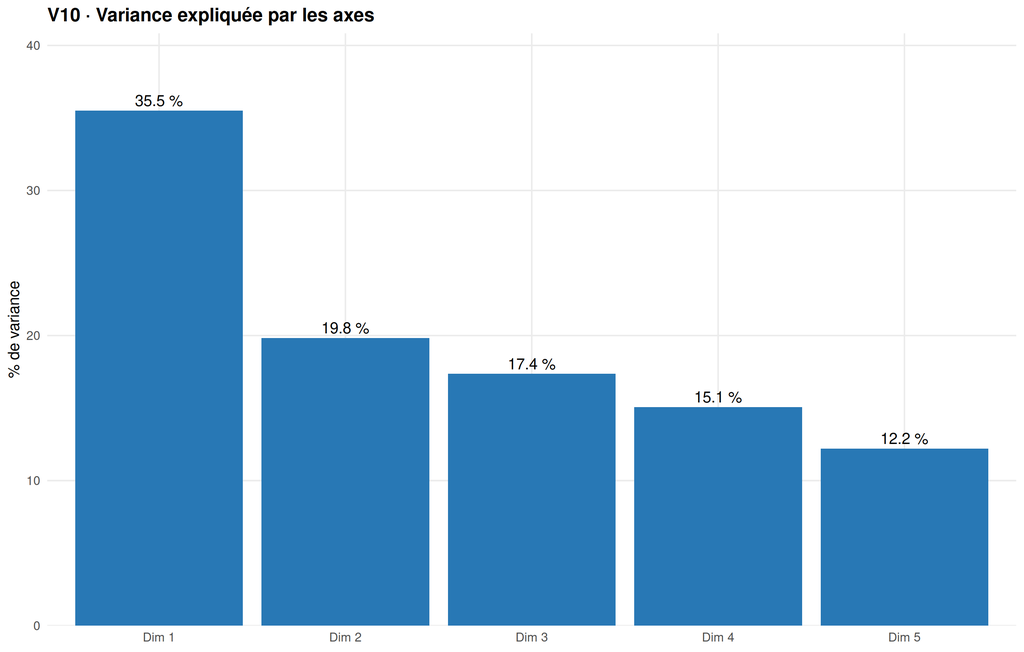

```r
acp <- NULL
if (nrow(d_acp) > length(quanti) && all(vapply(d_acp[quanti], sd, numeric(1)) > 0)) {
  acp <- prcomp(d_acp[quanti], center = TRUE, scale. = TRUE)
  inertie <- 100 * acp$sdev^2 / sum(acp$sdev^2)
  axes <- data.frame(axe = paste0("Dim ", seq_along(inertie)),
                     pct = inertie, cumul = cumsum(inertie))
  tableau(axes)
  print(ggplot(axes, aes(axe, pct)) + geom_col(fill = "#2878B5") +
    geom_text(aes(label = sprintf("%.1f %%", pct)), vjust = -.4) +
    labs(title = "V10 · Variance expliquée par les axes", x = NULL, y = "% de variance") +
    scale_y_continuous(expand = expansion(mult = c(0, .15))))
} else {
  cat("ACP non calculable : effectif insuffisant ou mesure constante/manquante.\n")
}
```

**V11 — Projection des observations.** Examiner les regroupements et leur lien avec la provenance. **V12 — Cercle des corrélations.** Les flèches indiquent les relations des mesures avec les axes. Leur longueur sur ce plan renseigne sur la qualité de représentation ; deux flèches courtes ne permettent pas de conclure sur la relation entre les variables.

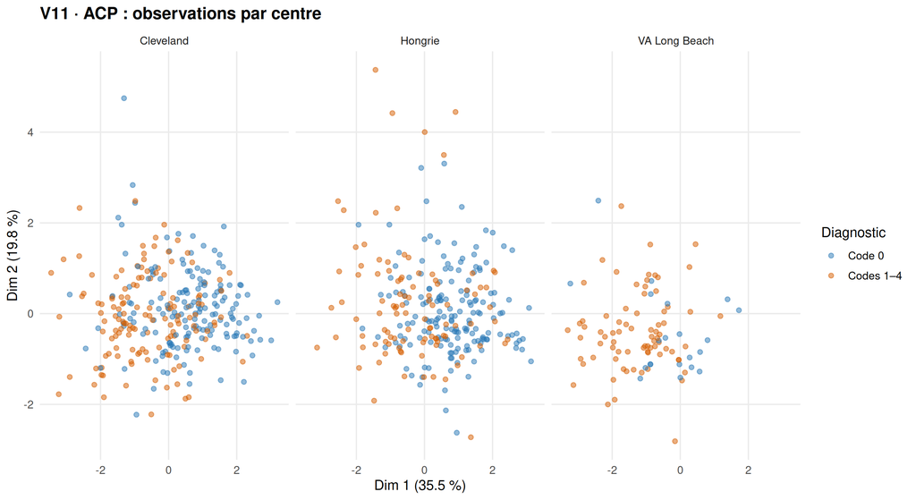

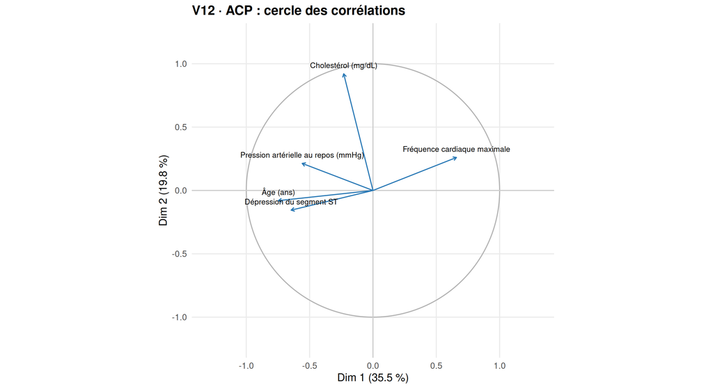

```r
if (!is.null(acp)) {
  scores <- data.frame(acp$x[, 1:2], diagnostic = d_acp$diagnostic,
                       provenance = d_acp$provenance)
  noms_axes <- sprintf("Dim %d (%.1f %%)", 1:2, inertie[1:2])
  print(ggplot(scores, aes(PC1, PC2, color = diagnostic)) +
    geom_point(alpha = .5) + facet_wrap(~provenance) +
    scale_color_manual(values = palette_diagnostic, na.value = "grey60") +
    labs(title = "V11 · ACP : observations par centre", x = noms_axes[1],
         y = noms_axes[2], color = "Diagnostic"))
  coord <- sweep(acp$rotation[, 1:2], 2, acp$sdev[1:2], "*")
  charges <- data.frame(x = coord[, 1], y = coord[, 2],
                        variable = unname(libelles[rownames(coord)]))
  cercle <- data.frame(x = cos(seq(0, 2*pi, length.out = 200)),
                        y = sin(seq(0, 2*pi, length.out = 200)))
  print(ggplot() + geom_path(data = cercle, aes(x, y), color = "grey70") +
    geom_hline(yintercept = 0, color = "grey80") + geom_vline(xintercept = 0, color = "grey80") +
    geom_segment(data = charges, aes(x = 0, y = 0, xend = x, yend = y),
                 arrow = grid::arrow(length = grid::unit(.15, "cm")), color = "#2878B5") +
    geom_text(data = charges, aes(x, y, label = variable), size = 3, vjust = -1,
              check_overlap = FALSE) + coord_fixed(xlim = c(-1.3, 1.3), ylim = c(-1.2, 1.2)) +
    labs(title = "V12 · ACP : cercle des corrélations", x = noms_axes[1], y = noms_axes[2]))
}
```

## 8 Choisir les visualisations

Ce tableau sert de carnet de décision. Remplir la dernière colonne après examen, et préciser les variables ou centres intéressants. Aucun graphique de ce notebook n’est ajouté automatiquement à l’application.

| ID | Visualisation | Question traitée | Choix / remarque |
| --- | --- | --- | --- |
| V01 | Carte des NA | Quelles variables sont disponibles dans chaque centre ? | À choisir |
| V02 | Effectifs par centre et diagnostic | Quelle est la composition de l’échantillon ? | À choisir |
| V03 | Histogrammes | Quelles formes ont les distributions ? | À choisir |
| V04 | Fréquences des catégories | Quelles modalités sont fréquentes ou rares ? | À choisir |
| V05 | Boîtes et points par diagnostic | Comment les mesures diffèrent-elles entre groupes ? | À choisir |
| V06 | Boîtes par diagnostic et centre | Les différences se retrouvent-elles dans chaque centre ? | À choisir |
| V07 | Proportions et IC par modalité | Quelles catégories présentent des proportions différentes ? | À choisir |
| V08 | Corrélations et effectifs par paire | Quelles mesures sont associées ? | À choisir |
| V09 | Nuage de points par centre | Quelle forme prend une relation particulière ? | À choisir |
| V10 | Inertie ACP | Quelle part de la variance résume chaque axe ? | À choisir |
| V11 | Individus ACP | Quels profils multivariés observe-t-on ? | À choisir |
| V12 | Cercle des corrélations | Quelles mesures structurent le plan ACP ? | À choisir |

Pour chaque graphique retenu, noter les effectifs, les exclusions dues aux NA, les unités, la définition du diagnostic et la population à laquelle il se rapporte. Les centres constituent des échantillons hospitaliers distincts ; les proportions observées ne représentent pas une prévalence en population générale.

## 9 Reproductibilité

Documentation locale : `dataset/heart-disease.names`. Source : UCI Heart Disease, Janosi, Steinbrunn, Pfisterer et Detrano (1989), DOI `10.24432/C52P4X`, licence CC BY 4.0. Les règles de nettoyage sont détaillées dans `R/import.R`.